## Project title:Bitcoin Historical price Regression Analysis

## College: BMSIT

## Email: pmprasunn457@gmail.com

## Introduction:

A cryptocurrency (or crypto currency) is a digital asset designed to work as a medium of exchange that uses cryptography to secure its transactions, to control the creation of additional units, and to verify the transfer of assets. Cryptocurrencies are classified as a subset of digital currencies and are also classified as a subset of alternative currencies and virtual currencies. Cryptocurrencies use decentralized control as opposed to centralized electronic money and central banking systems. The decentralized control of each cryptocurrency works through a blockchain, which is a public transaction database, functioning as a distributed ledger.

## BITCOIN:

Bittcoin is a cryptocurrency and worldwide payment system. It is the first decentralized digital currency, as the system works without a central bank or single administrator. The network is peer-to-peer and transactions take place between users directly, without an intermediary. These transactions are verified by network nodes through the use of cryptography and recorded in a public distributed ledger called a blockchain. Bitcoin was invented by an unknown person or group of people under the name Satoshi Nakamoto and released as open-source software in 2009. Bitcoins are created as a reward for a process known as mining. They can be exchanged for other currencies, products, and services. As of February 2015, over 100,000 merchants and vendors accepted bitcoin as payment. Research produced by the University of Cambridge estimates that in 2017, there are 2.9 to 5.8 million unique users using a cryptocurrency wallet, most of them using bitcoin.

## USD per Bitcoin if all bitcoin is mined

```r
USD=1610000000000 # 1.61 Trillion USD in circulation
Bitcoin=21000000   # 21 Million Bitcoin (Most Bitcoin that will be in Circulation)
Value=USD/Bitcoin  # Value of Bitcoin compared to current dollar
cat("Value=",Value)
```

```
## Value= 76666.67
```

## Bitcoin Data Insights

1.Reading the BITCOIN Data Set

```r
setwd("~/")#Setting the working directory
#reading the file
BTC <- read.csv(paste("bitcoin_dataset.csv", sep=" "))
```

## Summary of the BItcoin Data set

```r
library(psych)
summary(BTC)
```

```
##                   Date      btc_market_price   btc_total_bitcoins
##  2009-11-10 00:00:00:   1   Min.   :   0.000   Min.   : 1339450
##  2009-11-11 00:00:00:   1   1st Qu.:   5.177   1st Qu.: 7634838
##  2009-11-12 00:00:00:   1   Median : 213.115   Median :11965900
##  2009-11-13 00:00:00:   1   Mean   : 471.826   Mean   :10976895
##  2009-11-14 00:00:00:   1   3rd Qu.: 546.285   3rd Qu.:14816719
##  2009-11-15 00:00:00:   1   Max.   :7437.543   Max.   :16669275
##  (Other)            :2914
##  btc_market_cap      btc_trade_volume    btc_blocks_size
##  Min.   :0.000e+00   Min.   :0.000e+00   Min.   :     0.0
##  1st Qu.:4.556e+07   1st Qu.:2.226e+05   1st Qu.:   526.5
##  Median :2.910e+09   Median :7.884e+06   Median : 11733.0
##  Mean   :7.290e+09   Mean   :3.161e+07   Mean   : 30700.7
##  3rd Qu.:7.179e+09   3rd Qu.:2.444e+07   3rd Qu.: 48666.2
##  Max.   :1.239e+11   Max.   :1.267e+09   Max.   :140294.6
##                      NA's   :21
##  btc_avg_block_size  btc_n_orphaned_blocks btc_n_transactions_per_block
##  Min.   :0.0002152   Min.   :0.0000        Min.   :   1.0
##  1st Qu.:0.0204443   1st Qu.:0.0000        1st Qu.:  46.0
##  Median :0.1750999   Median :0.0000        Median : 348.0
##  Mean   :0.3180708   Mean   :0.3623        Mean   : 609.3
##  3rd Qu.:0.5971502   3rd Qu.:0.0000        3rd Qu.:1042.5
##  Max.   :1.0466060   Max.   :7.0000        Max.   :2436.1
##
##  btc_median_confirmation_time btc_hash_rate      btc_difficulty
##  Min.   : 0.000               Min.   :       0   Min.   :1.000e+00
##  1st Qu.: 0.000               1st Qu.:      10   1st Qu.:1.468e+06
##  Median : 7.767               Median :    4127   Median :5.109e+08
##  Mean   : 7.130               Mean   :  828840   Mean   :1.099e+11
##  3rd Qu.: 9.852               3rd Qu.:  490384   3rd Qu.:6.225e+10
##  Max.   :47.733               Max.   :12999790   Max.   :1.453e+12
##
##  btc_miners_revenue btc_transaction_fees btc_cost_per_transaction_percent
##  Min.   :       0   Min.   :  0.000      Min.   :      0.0
##  1st Qu.:   39709   1st Qu.:  6.253      1st Qu.:      1.2
##  Median :  769083   Median : 17.546      Median :      2.6
##  Mean   : 1280992   Mean   : 45.727      Mean   :   1918.6
##  3rd Qu.: 1687000   3rd Qu.: 44.974      3rd Qu.:      6.4
##  Max.   :15347363   Max.   :668.132      Max.   :2000000.0
##
```

[output cut: 17 more lines]

```
##  Min.   :    49                                      Min.   :    2450
##  1st Qu.:  6034                                      1st Qu.:  431346
##  Median : 30921                                      Median : 1025858
##  Mean   : 56864                                      Mean   : 1486692
##  3rd Qu.: 94479                                      3rd Qu.: 1938697
##  Max.   :286896                                      Max.   :45992223
##
##  btc_estimated_transaction_volume btc_estimated_transaction_volume_usd
##  Min.   :      0                  Min.   :0.000e+00
##  1st Qu.:  83286                  1st Qu.:6.869e+05
##  Median : 170951                  Median :3.070e+07
##  Mean   : 195545                  Mean   :1.124e+08
##  3rd Qu.: 254403                  3rd Qu.:1.097e+08
##  Max.   :5825066                  Max.   :2.396e+09
##
```

```r
str(BTC)
```

```
## 'data.frame':    2920 obs. of  24 variables:
##  $ Date                                               : Factor w/ 2920 levels "2009-11-10 00:00:00",..: 1 2 3 4 5 6 7 8 9 10 ...
##  $ btc_market_price                                   : num  0 0 0 0 0 0 0 0 0 0 ...
##  $ btc_total_bitcoins                                 : num  1339450 1342900 1346400 1349900 1354050 ...
##  $ btc_market_cap                                     : num  0 0 0 0 0 0 0 0 0 0 ...
##  $ btc_trade_volume                                   : num  0 0 0 0 0 0 0 0 0 0 ...
##  $ btc_blocks_size                                    : num  0 0 0 0 0 0 0 0 0 0 ...
##  $ btc_avg_block_size                                 : num  0.000215 0.000323 0.000215 0.000242 0.000216 ...
##  $ btc_n_orphaned_blocks                              : num  0 0 0 0 0 0 0 0 0 0 ...
##  $ btc_n_transactions_per_block                       : num  1 1 1 1 1 1 1 1 1 1 ...
##  $ btc_median_confirmation_time                       : num  0 0 0 0 0 0 0 0 0 0 ...
##  $ btc_hash_rate                                      : num  3.53e-06 3.43e-06 3.48e-06 3.48e-06 4.13e-06 ...
##  $ btc_difficulty                                     : num  1 1 1 1 1 1 1 1 1 1 ...
##  $ btc_miners_revenue                                 : num  0 0 0 0 0 0 0 0 0 0 ...
##  $ btc_transaction_fees                               : num  0 0 0 0 0 0 0 0 0 0 ...
##  $ btc_cost_per_transaction_percent                   : num  0 19.2 0 673.1 0 ...
##  $ btc_cost_per_transaction                           : num  0 0 0 0 0 0 0 0 0 0 ...
##  $ btc_n_unique_addresses                             : num  71 71 70 73 83 96 100 91 79 73 ...
##  $ btc_n_transactions                                 : num  71 78 70 73 83 96 100 91 79 73 ...
##  $ btc_n_transactions_total                           : num  26958 27036 27106 27179 27262 ...
##  $ btc_n_transactions_excluding_popular               : num  71 78 70 73 83 96 100 91 79 73 ...
##  $ btc_n_transactions_excluding_chains_longer_than_100: num  71 78 70 73 83 96 100 91 79 73 ...
##  $ btc_output_volume                                  : num  3550 93450 3500 4100 4150 ...
##  $ btc_estimated_transaction_volume                   : num  0 18000 0 520 0 0 0 0 0 0 ...
##  $ btc_estimated_transaction_volume_usd               : num  0 0 0 0 0 0 0 0 0 0 ...
```

```r
describe(BTC)
```

```
##                                                     vars    n         mean
## Date*                                                  1 2920 1.460500e+03
## btc_market_price                                       2 2920 4.718300e+02
## btc_total_bitcoins                                     3 2920 1.097689e+07
## btc_market_cap                                         4 2920 7.290293e+09
## btc_trade_volume                                       5 2899 3.161043e+07
## btc_blocks_size                                        6 2920 3.070073e+04
## btc_avg_block_size                                     7 2920 3.200000e-01
## btc_n_orphaned_blocks                                  8 2920 3.600000e-01
## btc_n_transactions_per_block                           9 2920 6.093000e+02
## btc_median_confirmation_time                          10 2920 7.130000e+00
## btc_hash_rate                                         11 2920 8.288403e+05
## btc_difficulty                                        12 2920 1.099002e+11
## btc_miners_revenue                                    13 2920 1.280992e+06
## btc_transaction_fees                                  14 2920 4.573000e+01
## btc_cost_per_transaction_percent                      15 2920 1.918640e+03
## btc_cost_per_transaction                              16 2920 1.168000e+01
## btc_n_unique_addresses                                17 2920 1.712510e+05
## btc_n_transactions                                    18 2920 9.227195e+04
## btc_n_transactions_total                              19 2920 5.985843e+07
## btc_n_transactions_excluding_popular                  20 2920 8.501016e+04
## btc_n_transactions_excluding_chains_longer_than_100   21 2920 5.686395e+04
## btc_output_volume                                     22 2920 1.486692e+06
## btc_estimated_transaction_volume                      23 2920 1.955447e+05
## btc_estimated_transaction_volume_usd                  24 2920 1.123620e+08
##                                                               sd
## Date*                                               8.430800e+02
## btc_market_price                                    9.349600e+02
## btc_total_bitcoins                                  4.456721e+06
## btc_market_cap                                      1.548875e+10
## btc_trade_volume                                    8.273604e+07
## btc_blocks_size                                     3.926642e+04
## btc_avg_block_size                                  3.400000e-01
## btc_n_orphaned_blocks                               8.400000e-01
## btc_n_transactions_per_block                        6.533900e+02
## btc_median_confirmation_time                        5.050000e+00
## btc_hash_rate                                       1.799654e+06
## btc_difficulty                                      2.364067e+11
## btc_miners_revenue                                  1.999356e+06
## btc_transaction_fees                                7.885000e+01
```

[output cut: 145 more lines]

```
## btc_median_confirmation_time                            1.25 9.000000e-02
## btc_hash_rate                                          10.22 3.330409e+04
## btc_difficulty                                          9.60 4.374902e+09
## btc_miners_revenue                                     13.10 3.699973e+04
## btc_transaction_fees                                   13.35 1.460000e+00
## btc_cost_per_transaction_percent                     1120.49 9.490500e+02
## btc_cost_per_transaction                                4.53 2.500000e-01
## btc_n_unique_addresses                                 -0.42 3.452750e+03
## btc_n_transactions                                     -0.35 1.802380e+03
## btc_n_transactions_total                                0.50 1.380483e+06
## btc_n_transactions_excluding_popular                   -0.36 1.809540e+03
## btc_n_transactions_excluding_chains_longer_than_100     0.21 1.212480e+03
## btc_output_volume                                     117.99 4.220202e+04
## btc_estimated_transaction_volume                      180.14 4.992490e+03
## btc_estimated_transaction_volume_usd                   20.83 4.446656e+06
```

```r
View(BTC)
```

```r
BTC$Days <- 1:nrow(BTC) #Add column that adds a count of days for each row
BTC$Date <- as.Date(BTC$Date) #Format Date as Date
BTC2 <- subset(BTC, BTC$btc_median_confirmation_time>0) #Subset of data that is clean
```

## Historical Bitcoin Value

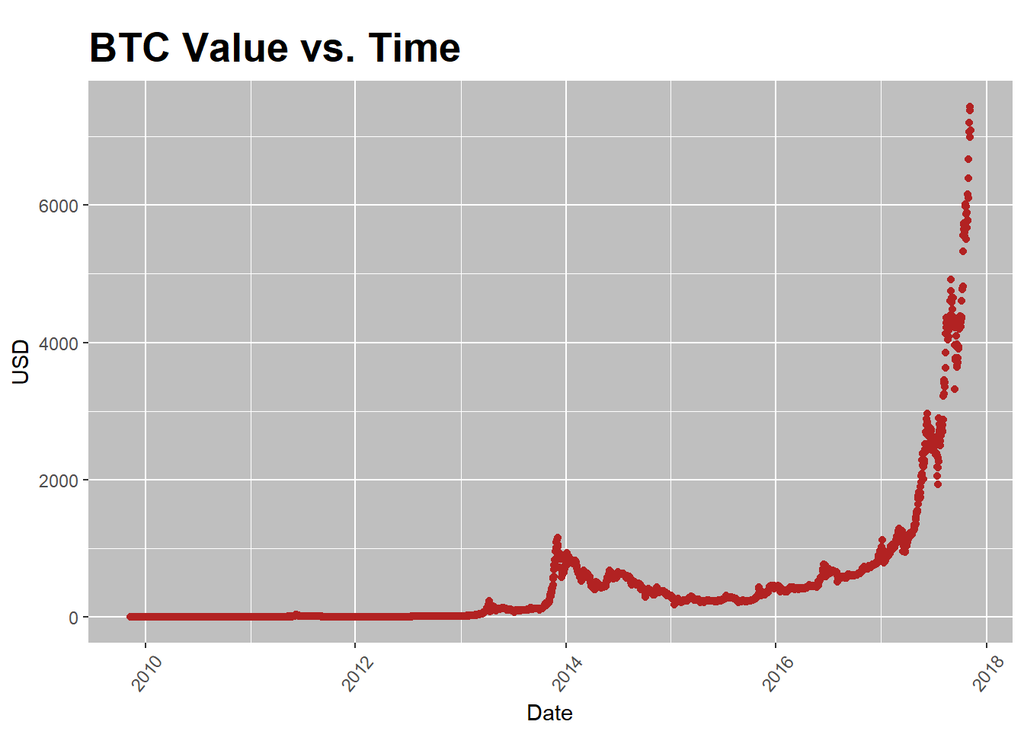

```r
library(ggplot2)
ggplot(BTC, aes(BTC$Date, BTC$btc_market_price)) +
  geom_point(color="firebrick") +
  ggtitle('BTC Value vs. Time') +
  theme(plot.title = element_text(size=20, face="bold",
    margin = margin(10, 0, 10, 0)))+
  labs(x="Date", y="USD")+
  theme(axis.text.x=element_text(angle=50, vjust=0.5)) +
  theme(panel.background = element_rect(fill = 'grey75'))
```

From the graph we can see that the value of bitcoin with respect to dollar has increased exponentially.

## Correlation between variables

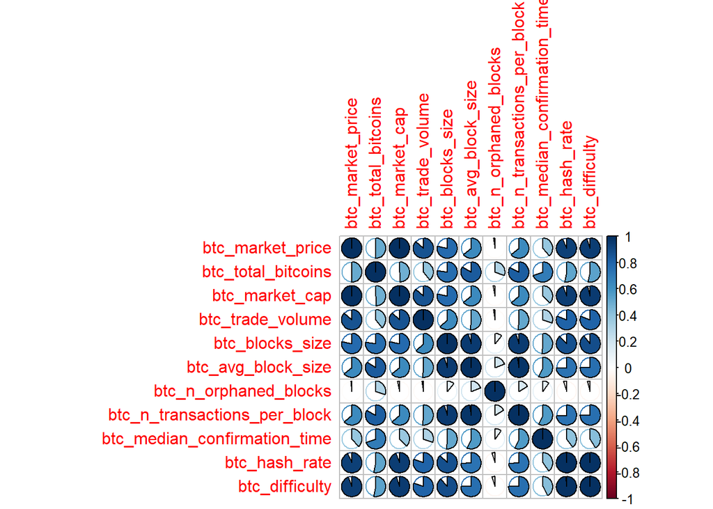

```r
BTC<-na.omit(BTC)
library(corrplot)
cor <- cor(BTC[,2:12])
#corrplot
corrplot(cor, method = "pie")
```

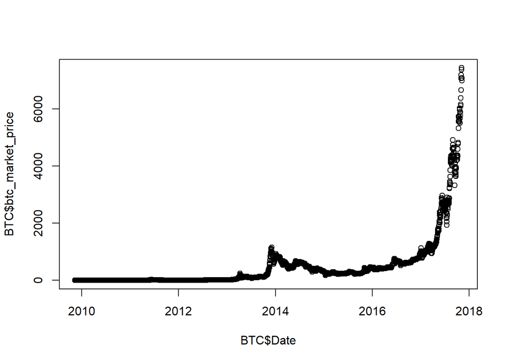

```r
#Bitcoin date vs market price
plot(BTC$Date, BTC$btc_market_price)
```

```r
#Bitcoin market price vs market cap
mod<-lm(btc_market_price~btc_market_cap, data=BTC)
mod1<-lm(btc_market_price~btc_estimated_transaction_volume_usd, data=BTC)
summary(mod)
```

```
##
## Call:
## lm(formula = btc_market_price ~ btc_market_cap, data = BTC)
##
## Residuals:
##      Min       1Q   Median       3Q      Max
## -105.646  -29.737   -8.419    3.797  280.916
##
## Coefficients:
##                 Estimate Std. Error t value Pr(>|t|)
## (Intercept)    3.208e+01  9.563e-01   33.55   <2e-16 ***
## btc_market_cap 6.029e-08  5.569e-11 1082.63   <2e-16 ***
## ---
## Signif. codes:  0 '***' 0.001 '**' 0.01 '*' 0.05 '.' 0.1 ' ' 1
##
## Residual standard error: 46.59 on 2897 degrees of freedom
## Multiple R-squared:  0.9975, Adjusted R-squared:  0.9975
## F-statistic: 1.172e+06 on 1 and 2897 DF,  p-value: < 2.2e-16
```

```r
summary(mod1)
```

```
##
## Call:
## lm(formula = btc_market_price ~ btc_estimated_transaction_volume_usd,
##     data = BTC)
##
## Residuals:
##     Min      1Q  Median      3Q     Max
## -3630.5   -63.4   -59.9    20.9  3372.0
##
## Coefficients:
##                                       Estimate Std. Error t value Pr(>|t|)
## (Intercept)                          6.336e+01  6.940e+00   9.131   <2e-16
## btc_estimated_transaction_volume_usd 3.629e-06  2.607e-08 139.193   <2e-16
##
## (Intercept)                          ***
## btc_estimated_transaction_volume_usd ***
## ---
## Signif. codes:  0 '***' 0.001 '**' 0.01 '*' 0.05 '.' 0.1 ' ' 1
##
## Residual standard error: 338.4 on 2897 degrees of freedom
## Multiple R-squared:  0.8699, Adjusted R-squared:  0.8699
## F-statistic: 1.937e+04 on 1 and 2897 DF,  p-value: < 2.2e-16
```

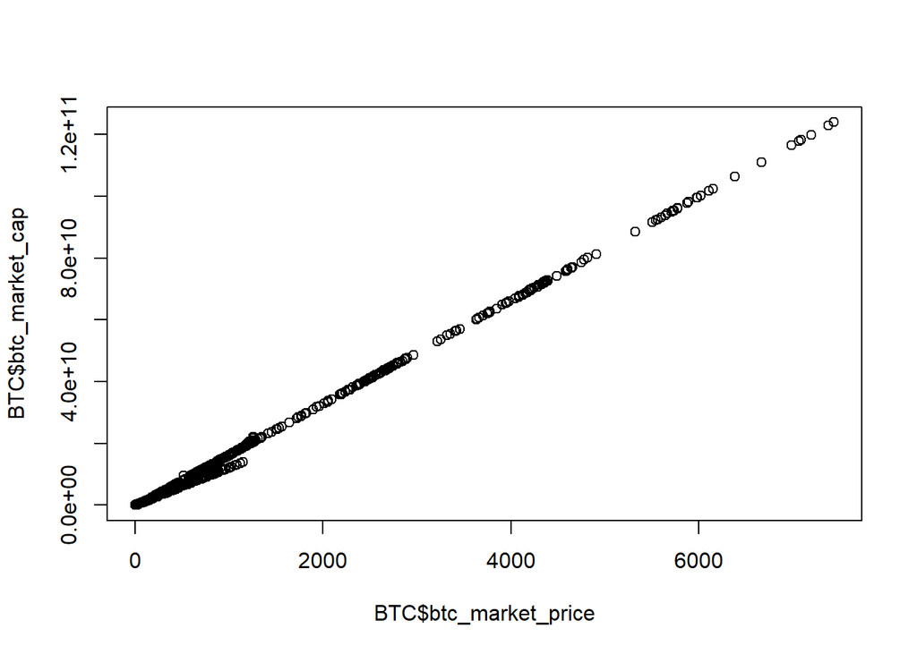

```r
plot(BTC$btc_market_price,BTC$btc_market_cap)
```

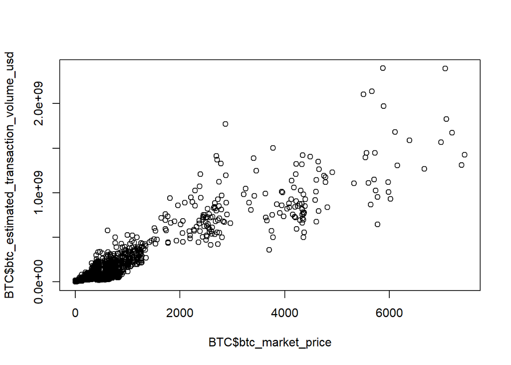

```r
plot(BTC$btc_market_price,BTC$btc_estimated_transaction_volume_usd)
```

## Market Price Vs Miners Revenue

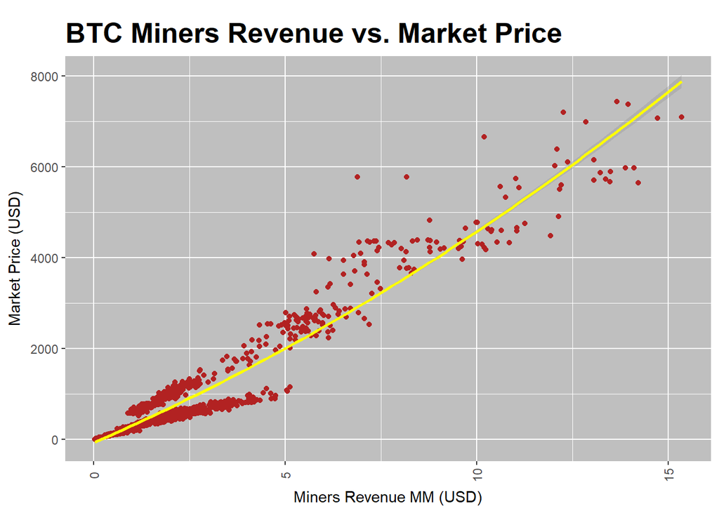

```r
ggplot(BTC2, aes(BTC2$btc_miners_revenue/1000000, BTC2$btc_market_price)) +
  geom_point(color="firebrick") +
  ggtitle('BTC Miners Revenue vs. Market Price') +
  theme(plot.title = element_text(size=19.5, face="bold",
    margin = margin(10, 0, 10, 0)))+
  labs(x="Miners Revenue MM (USD)", y="Market Price (USD)")+
  theme(axis.text.x=element_text(angle=90, vjust=0.5)) +
  theme(panel.background = element_rect(fill = 'grey75'))+
  stat_smooth(method = "lm",  formula = y ~ poly(x,2), col = "yellow")
```

## Difficulty vs. Market Price

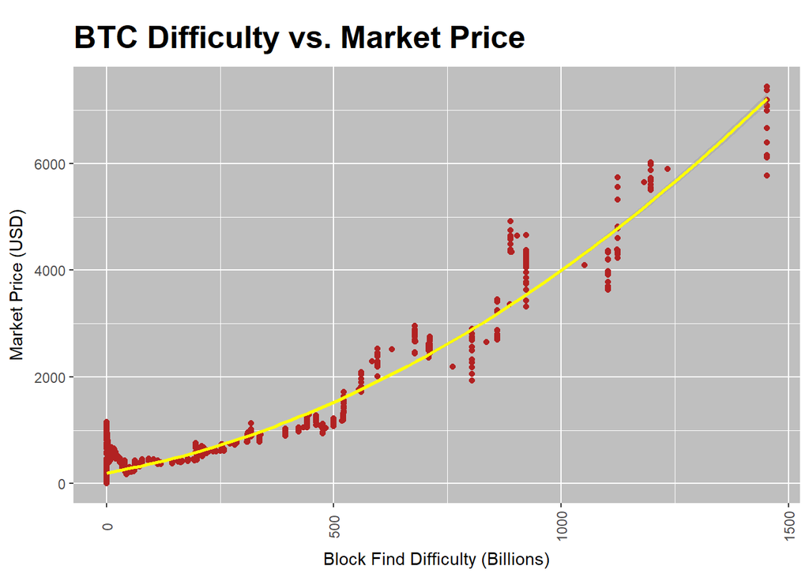

```r
ggplot(BTC2, aes(BTC2$btc_difficulty/1000000000, BTC2$btc_market_price)) +
  geom_point(color="firebrick") +
  ggtitle('BTC Difficulty vs. Market Price') +
  theme(plot.title = element_text(size=19.5, face="bold",
    margin = margin(10, 0, 10, 0)))+
  labs(x="Block Find Difficulty (Billions)", y="Market Price (USD)")+
  theme(axis.text.x=element_text(angle=90, vjust=0.5)) +
  theme(panel.background = element_rect(fill = 'grey75'))+
  stat_smooth(method = "lm",  formula = y ~ poly(x,2), col = "yellow")
```

## Hash Rate vs. Market Price

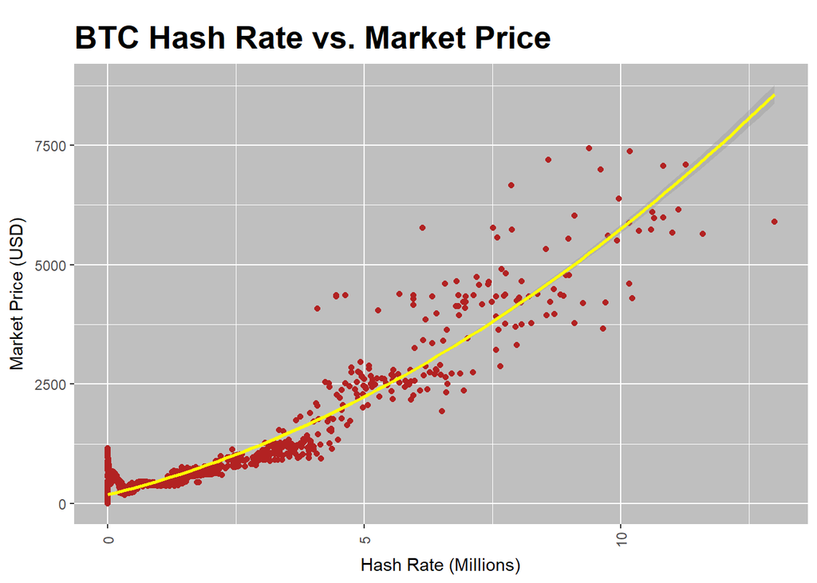

```r
ggplot(BTC2, aes(BTC2$btc_hash_rate/1000000, BTC2$btc_market_price)) +
  geom_point(color="firebrick") +
  ggtitle('BTC Hash Rate vs. Market Price') +
  theme(plot.title = element_text(size=19.5, face="bold",
    margin = margin(10, 0, 10, 0)))+
  labs(x="Hash Rate (Millions)", y="Market Price (USD)")+
  theme(axis.text.x=element_text(angle=90, vjust=0.5)) +
  theme(panel.background = element_rect(fill = 'grey75'))+
  stat_smooth(method = "lm",  formula = y ~ poly(x,2), col = "yellow")
```

## Loading Library’s

```r
library(knitr)
library(pander)
library(tidyverse)
library(broom)
library(DataCombine)
library(caret)
```

## Summary of Regression Model

```r
lmfit1<-lm(BTC2$btc_market_price~BTC2$btc_market_cap)
panderOptions("digits", 2)
pander(lmfit1, caption = "Linear Model: Market Price ~ Market Capitalization")
```

Linear Model: Market Price ~ Market Capitalization

|  | Estimate | Std. Error | t value | Pr(>\|t\|) |
| --- | --- | --- | --- | --- |
| **(Intercept)** | 46 | 1.2 | 38 | 3.4e-241 |
| **BTC2$btc_market_cap** | 6e-08 | 6.2e-11 | 973 | 0 |

```r
R1=summary(lmfit1)$r.squared
cat("R-Squared = ", R1)
```

```
## R-Squared =  0.9977156
```

Market Capitalization is signficant to Market Price.

## Residuals

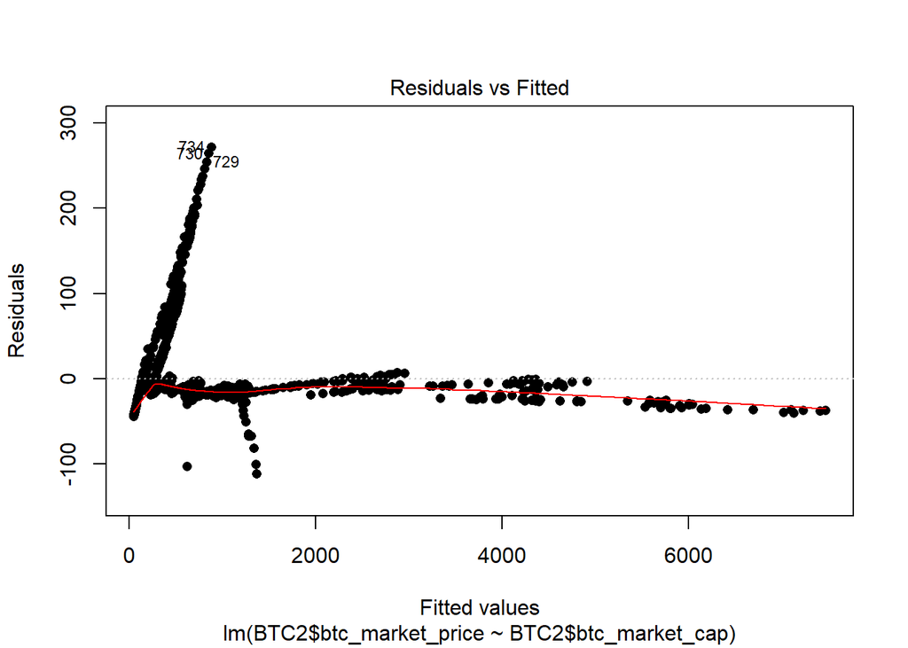

```r
plot(lmfit1, pch=16, which=1)
```

##Estimated USD Transaction Volume vs. Market Price

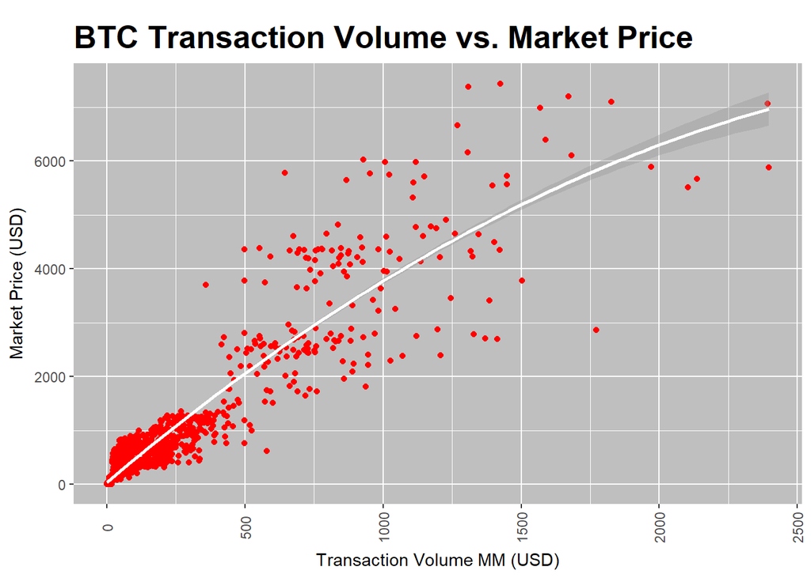

```r
ggplot(BTC2, aes(BTC2$btc_estimated_transaction_volume_usd/1000000, BTC2$btc_market_price)) +
  geom_point(color="red") +
  ggtitle('BTC Transaction Volume vs. Market Price') +
  theme(plot.title = element_text(size=19.5, face="bold",
    margin = margin(10, 0, 10, 0)))+
  labs(x="Transaction Volume MM (USD)", y="Market Price (USD)")+
  theme(axis.text.x=element_text(angle=90, vjust=0.5)) +
  theme(panel.background = element_rect(fill = 'grey75'))+
  stat_smooth(method = "lm",  formula = y ~ poly(x,2), col = "white")
```

```r
lmfit2<-lm(BTC2$btc_market_price~poly(BTC2$btc_estimated_transaction_volume_usd,2))
panderOptions("digits", 2)
pander(lmfit2, caption = "Linear Model: Market Price ~ Estimated Transaction Volume (USD) Squared")
```

Linear Model: Market Price ~ Estimated Transaction Volume (USD) Squared (continued below)

|  | Estimate | Std. Error |
| --- | --- | --- |
| **(Intercept)** | 635 | 8.1 |
| **poly(BTC2$btc_estimated_transaction_volume_usd, 2)1** | 44731 | 377 |
| **poly(BTC2$btc_estimated_transaction_volume_usd, 2)2** | -4514 | 377 |

|  | t value | Pr(>\|t\|) |
| --- | --- | --- |
| **(Intercept)** | 78 | 0 |
| **poly(BTC2$btc_estimated_transaction_volume_usd, 2)1** | 119 | 0 |
| **poly(BTC2$btc_estimated_transaction_volume_usd, 2)2** | -12 | 4.9e-32 |

```r
R2=summary(lmfit2)$r.squared
cat("R-Squared = ", R2)
```

```
## R-Squared =  0.8678923
```

Transaction volume is significant to market price ##Residuals

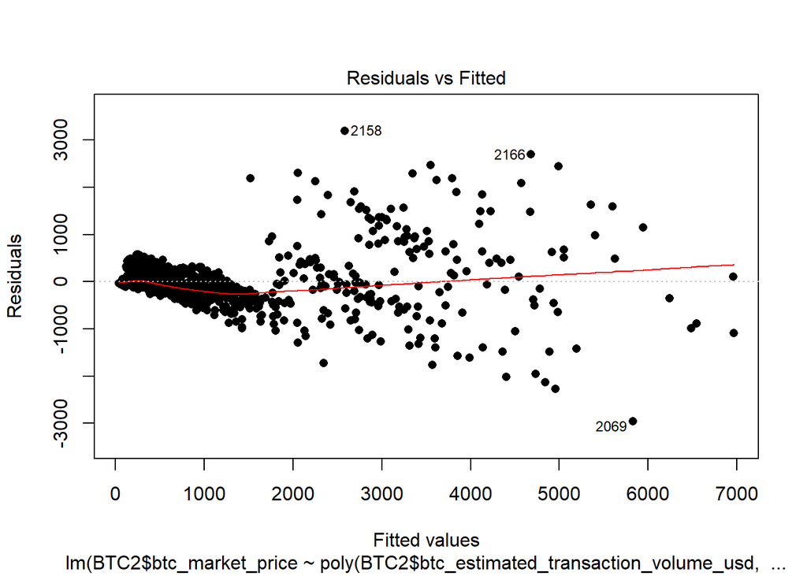

```r
plot(lmfit2, pch=16, which=1)
```

the price increases the variability increases ##Regression model

```r
lmfit7 <- lm(BTC2$btc_market_price ~ poly(BTC2$btc_estimated_transaction_volume_usd, 2) + poly(BTC2$btc_miners_revenue, degree=2))

panderOptions("digits", 2)
pander(lmfit7, caption = "Linear Model: Market Price ~ Miners Revenue Squared + Count of Transactions Squared")
```

|  | Estimate | Std. Error |
| --- | --- | --- |
| **(Intercept)** | 635 | 4.4 |
| **poly(BTC2$btc_estimated_transaction_volume_usd, 2)1** | 16300 | 462 |
| **poly(BTC2$btc_estimated_transaction_volume_usd, 2)2** | -6159 | 269 |
| **poly(BTC2$btc_miners_revenue, degree = 2)1** | 31297 | 463 |
| **poly(BTC2$btc_miners_revenue, degree = 2)2** | 6864 | 268 |

|  | t value | Pr(>\|t\|) |
| --- | --- | --- |
| **(Intercept)** | 143 | 0 |
| **poly(BTC2$btc_estimated_transaction_volume_usd, 2)1** | 35 | 2e-215 |
| **poly(BTC2$btc_estimated_transaction_volume_usd, 2)2** | -23 | 4.7e-104 |
| **poly(BTC2$btc_miners_revenue, degree = 2)1** | 68 | 0 |
| **poly(BTC2$btc_miners_revenue, degree = 2)2** | 26 | 2.9e-126 |

```r
R7=summary(lmfit7)$r.squared
cat("R-Squared = ", R7)
```

```
## R-Squared =  0.9604765
```

## Percentage Change

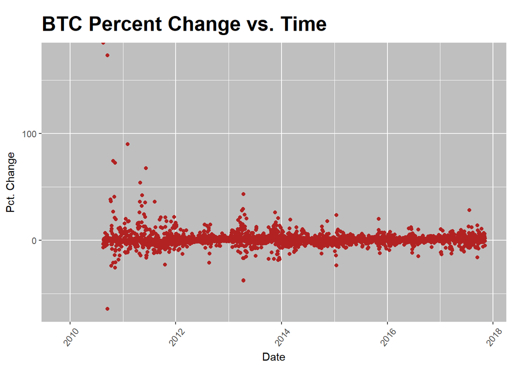

```r
BTC<-mutate(BTC, pChange=(BTC$btc_market_price-lag(BTC$btc_market_price))/lag(BTC$btc_market_price)*100) #Add column for percentage of change

ggplot(BTC, aes(BTC$Date, BTC$pChange)) +
  geom_point(color="firebrick") +
  ggtitle('BTC Percent Change vs. Time') +
  theme(plot.title = element_text(size=20, face="bold",
    margin = margin(10, 0, 10, 0)))+
  labs(x="Date", y="Pct. Change")+
  theme(axis.text.x=element_text(angle=50, vjust=0.5)) +
  theme(panel.background = element_rect(fill = 'grey75'))
```

##Mutate Data in Percent Change

```r
library(zoo)
```

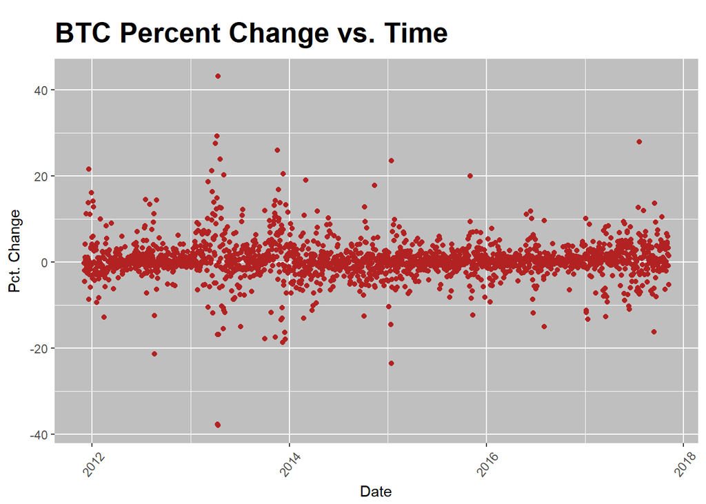

```r
BTC2$AVGtransactionvolume<-BTC2$btc_estimated_transaction_volume_usd
BTC2$AVGminersrevenue<-BTC2$btc_miners_revenue
BTC2$AVGmarketcap<-BTC2$btc_market_cap
BTC2$pctChange<-BTC2$btc_market_price
BTC2$AVGtotalbitcoins<-BTC2$btc_total_bitcoins

BTC11<- subset(BTC2, BTC2$AVGminersrevenue>0)
BTC11<-mutate(BTC11, pctChange=(BTC2$btc_market_price-lag(BTC2$btc_market_price))/lag(BTC2$btc_market_price)*100)
BTC11<-mutate(BTC11, AVGtransactionvolume=(BTC2$AVGtransactionvolume-lag(BTC2$AVGtransactionvolume))/lag(BTC2$AVGtransactionvolume)*100)
BTC11<-mutate(BTC11, AVGminersrevenue=(BTC2$AVGminersrevenue-lag(BTC2$AVGminersrevenue))/lag(BTC2$AVGminersrevenue)*100)
BTC11<-mutate(BTC11, AVGmarketcap=(BTC2$AVGmarketcap-lag(BTC2$AVGmarketcap))/lag(BTC2$AVGmarketcap)*100)
BTC11<-mutate(BTC11, AVGtotalbitcoins=(BTC2$AVGtotalbitcoins-lag(BTC2$AVGtotalbitcoins))/lag(BTC2$AVGtotalbitcoins)*100)

ggplot(BTC2, aes(BTC11$Date, BTC11$pctChange)) +
  geom_point(color="firebrick") +
  ggtitle('BTC Percent Change vs. Time') +
  theme(plot.title = element_text(size=20, face="bold",
    margin = margin(10, 0, 10, 0)))+
  labs(x="Date", y="Pct. Change")+
  theme(axis.text.x=element_text(angle=50, vjust=0.5)) +
  theme(panel.background = element_rect(fill = 'grey75'))
```

##Correlation Analysis of Transformed Variables

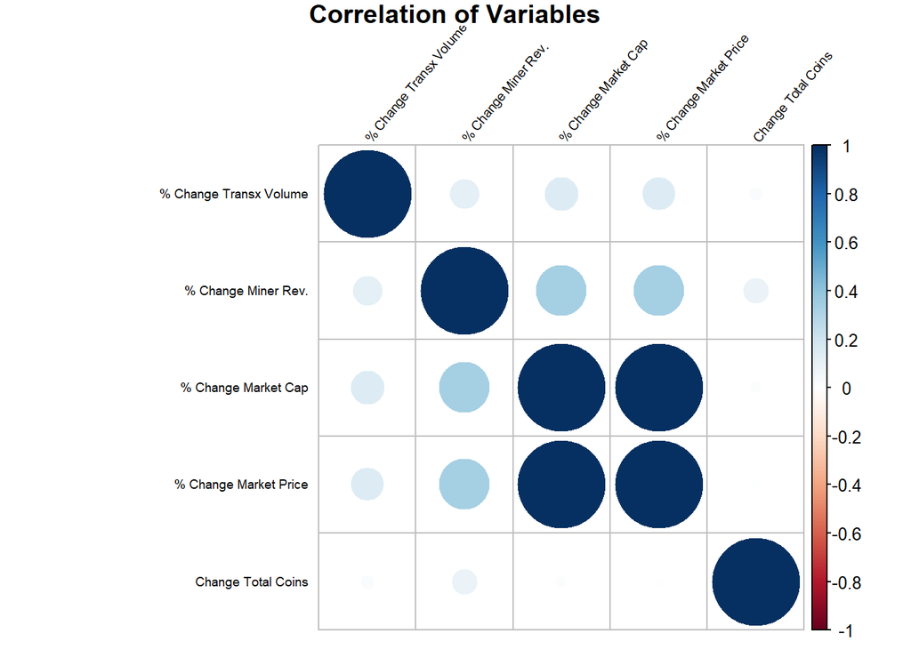

```r
cor2 <- cor(BTC11[c(2:2167),c(26:30)]) #selecting variables to include in correlation analysis

colnames(cor2) <- c("% Change Transx Volume", "% Change Miner Rev.","% Change Market Cap", "% Change Market Price","Change Total Coins")
rownames(cor2) <- c("% Change Transx Volume", "% Change Miner Rev.","% Change Market Cap","% Change Market Price", "Change Total Coins")

corrplot(cor2, method = "circle",  tl.srt = 50, tl.col = "black", tl.cex = 0.6, title = "Correlation of Variables", mar=c(0,0,1,0))
```

##What is the significance of these variables to the percent change in market price?

```r
lmfit8 <- lm(pctChange ~ AVGmarketcap+AVGtotalbitcoins, BTC11)

panderOptions("digits", 2)
pander(lmfit8, caption = "Linear Model: Market Price Change ~ Market Cap Change + Total Coins Change")
```

Linear Model: Market Price Change ~ Market Cap Change + Total Coins Change

|  | Estimate | Std. Error | t value | Pr(>\|t\|) |
| --- | --- | --- | --- | --- |
| **(Intercept)** | 0.0036 | 0.02 | 0.18 | 0.86 |
| **AVGmarketcap** | 0.99 | 0.0025 | 398 | 0 |
| **AVGtotalbitcoins** | -1 | 0.48 | -2.1 | 0.037 |

## T-Test

```r
t.test(BTC$btc_market_price,BTC$btc_market_cap)
```

```
##
##  Welch Two Sample t-test
##
## data:  BTC$btc_market_price and BTC$btc_market_cap
## t = -25.345, df = 2898, p-value < 2.2e-16
## alternative hypothesis: true difference in means is not equal to 0
## 95 percent confidence interval:
##  -7880838055 -6749000205
## sample estimates:
##    mean of x    mean of y
## 4.730802e+02 7.314920e+09
```

```r
t.test(BTC$btc_market_price,BTC$btc_total_bitcoins)
```

```
##
##  Welch Two Sample t-test
##
## data:  BTC$btc_market_price and BTC$btc_total_bitcoins
## t = -132.32, df = 2898, p-value < 2.2e-16
## alternative hypothesis: true difference in means is not equal to 0
## 95 percent confidence interval:
##  -11136901 -10811658
## sample estimates:
##    mean of x    mean of y
## 4.730802e+02 1.097475e+07
```

```r
t.test(BTC$btc_miners_revenue,BTC$btc_hash_rate)
```

```
##
##  Welch Two Sample t-test
##
## data:  BTC$btc_miners_revenue and BTC$btc_hash_rate
## t = 8.9353, df = 5733.2, p-value < 2.2e-16
## alternative hypothesis: true difference in means is not equal to 0
## 95 percent confidence interval:
##  349500.2 545962.4
## sample estimates:
## mean of x mean of y
## 1281695.1  833963.8
```

```r
t.test(BTC$btc_difficulty,BTC$btc_market_price)
```

```
##
##  Welch Two Sample t-test
##
## data:  BTC$btc_difficulty and BTC$btc_market_price
## t = 25.107, df = 2898, p-value < 2.2e-16
## alternative hypothesis: true difference in means is not equal to 0
## 95 percent confidence interval:
##  101936970198 119207754485
## sample estimates:
##    mean of x    mean of y
## 1.105724e+11 4.730802e+02
```

## Train Model and Test Percent Change

## Creating the training subset and test subset

```r
set.seed(1)
train2.index<-sample(1:nrow(BTC11),0.90*nrow(BTC11), replace=FALSE)
train2 <- BTC11[train2.index, ]
test2  <- BTC11[-train2.index,]
```

## Training and testing

```r
lmtrain2 <- lm(pctChange~AVGmarketcap+AVGtotalbitcoins, train2)
test2$p1 <- predict(lmtrain2,test2)
error=mean(abs(test2$p1-test2$pctChange))
cat("Mean Error = ", error)
```

```
## Mean Error =  0.06610463
```

Very small amount of error.

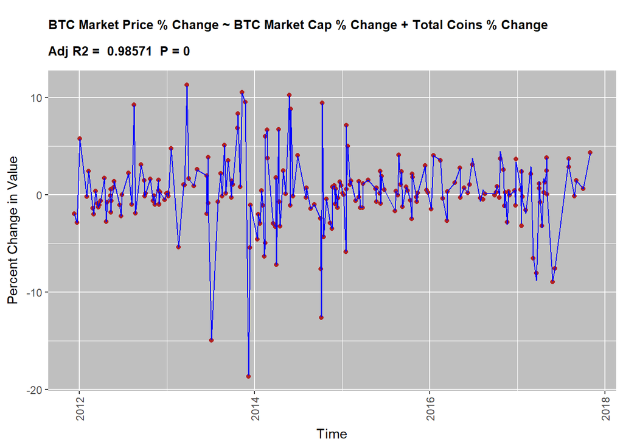

```r
ggplot(test2, aes(test2$Date)) +
  geom_point(aes(y=test2$pctChange),color="Firebrick") +
  geom_line(aes(y=test2$p1), color="Blue")+
  ggtitle('') +
  theme(plot.title = element_text(size=10, face="bold",
    margin = margin(10, 0, 10, 0)))+
  labs(x="Time", y="Percent Change in Value")+
  theme(axis.text.x=element_text(angle=90, vjust=0.5)) +
  theme(panel.background = element_rect(fill = 'grey75'))+
  labs(title = paste("BTC Market Price % Change ~ BTC Market Cap % Change + Total Coins % Change",
                     "\n\nAdj R2 = ",signif(summary(lmtrain2)$adj.r.squared, 5),
                     " P =",signif(summary(lmtrain2)$coef[2,4], 2)))
```